# Popular names

Week 6 Activity

Branson T Fausey

Sunday, 6 October 2024

# Set Up

```r
# load necessary packages
library(tidyverse)
library(dcData)
library(mosaic)
library(esquisse)
```

```r
# Load the BabyNames data into RStudio environment (from dcData package)
data("BabyNames")
```

# Activity

**Goal**: By the end of the activity, each team will create a graph (like Figure A.1 on p 159) showing ups and downs in the popularity of the names at your table according to the U.S. social security registry.

### Step 1

```r
## Helpful to look at the data a few different ways (see Ch 9 for more).
help(BabyNames)
BabyNames %>%
  head(5)
```

|  | name | sex | count | year |
| --- | --- | --- | --- | --- |
| 1 | Mary | F | 7065 | 1880 |
| 2 | Anna | F | 2604 | 1880 |
| 3 | Emma | F | 2003 | 1880 |
| 4 | Elizabeth | F | 1939 | 1880 |
| 5 | Minnie | F | 1746 | 1880 |

```r
nrow(BabyNames)
```

```
[1] 1792091
```

- The data frame consists of 4 variables across 1.79 million cases. Each case represents a name, given the gender and year.

### Step 2

[This should be done by hand on paper, nothing to show in the HTML doc]

### Step 3

##### What variable(s) from the raw data table do not appear at all in the graph?

- The ‘sex’ variable does not appear at all in the target graph, and ‘count’ appears to be transformed.

##### What variable(s) in the graph are similar to corresponding variables in the raw data table, but might have been transformed in some way?

- The ‘Popularity’ appears to be the ‘count’ variable of both male and females combined

### Step 4

##### Have cases been filtered out?

- All cases have been filtered out except for the desired names.

##### Have cases been grouped and summarized within groups in any way?

- Cases have been grouped by ‘name’ and ‘year’, removing the ‘sex’ variable.

##### Have any new variables been introduced? If so, what the relationship between the new variables and existing variables?

- It appears the only new variable is ‘Popularity’, which simply appears to be the ‘count’ of both males and females.

### Step 5

- Group the cases by ‘name’ and ‘year’.
- Filter out all the unwanted names.
- Summarise the ‘count’ variable to a sex-combined ‘total’ variable, which will be displyed as ‘Popularity’.

### Step 6

[This should be done by hand on paper, nothing to show in the HTML doc]

### Step 7

```r
GRdata <- BabyNames %>%
group_by(name, year) %>%
filter(name %in% c("Branson", "Emma", "Neil", "Susan")) %>%
summarise(total = sum(count))
```

### Graph It!

Here’s the sample code provided by the book:

```
GlyphReadyForm %>%
  ggplot(aes(x = year, y = total, group = name)) +
  geom_line(size = 1, alpha = 0.5, aes(color = name)) +
  ylab("Popularity") + xlab("Year")
```

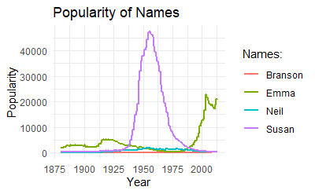

```r
ggplot(GRdata) +
    aes(x = year, y = total, colour = name) +
    geom_step(linewidth = 1) +
    scale_color_hue(direction = 1) +
    labs(
        x = "Year",
        y = "Popularity",
        title = "Popularity of Names",
        color = "Names:"
    ) +
    theme_minimal()
```

- The name ‘Susan’ really took off in popularity around the 1930s and 40s, and remained so until the 1970s. Emma was only a mildly popular name until the late 1900s. ‘Neil’ and ‘Branson’ are both not very popular names, but ‘Branson’ is certainly the least popular.

Note: if someone in your group has a name that hasn’t been registered with the US Social Security Administration for a baby born in the United States, it’s okay that the student’s name may not appear on the plot.